# Baseline Risk Factors for Change in Systolic Blood Pressure

11/25/2026

**Question:** Among participants without hypertension at entry, how does systolic blood pressure (SBP) change over follow-up, and is the rate of change associated with baseline age (per 10 years), sex, and BMI, after accounting for antihypertensive medication use at each visit?

The analysis includes 2,067 participants with 9,149 clinic visits (entry and scheduled visits at months 12 to 84). Visit SBP is the mean of the second and third readings.

## Mean SBP over Follow-up

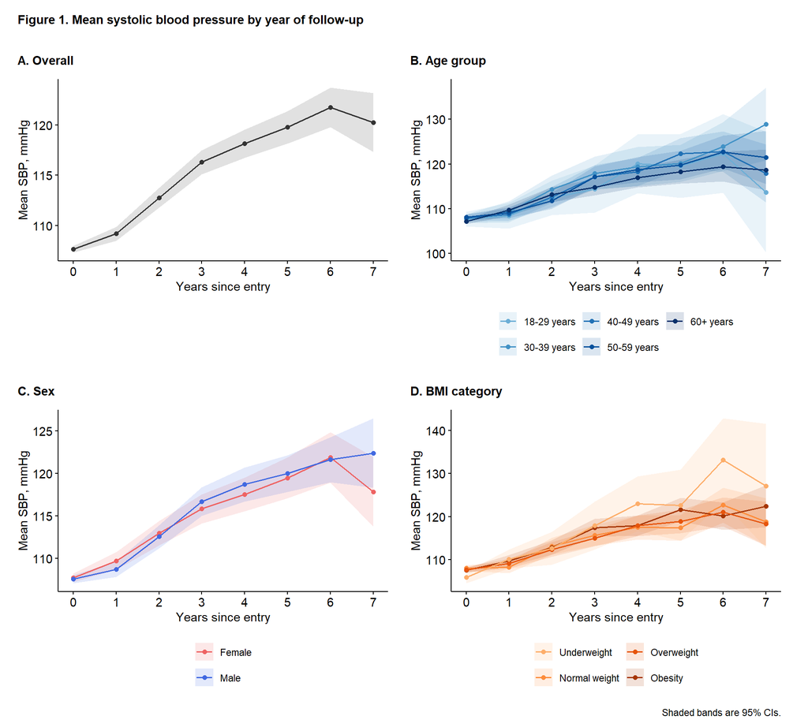

## Model Diagnostics

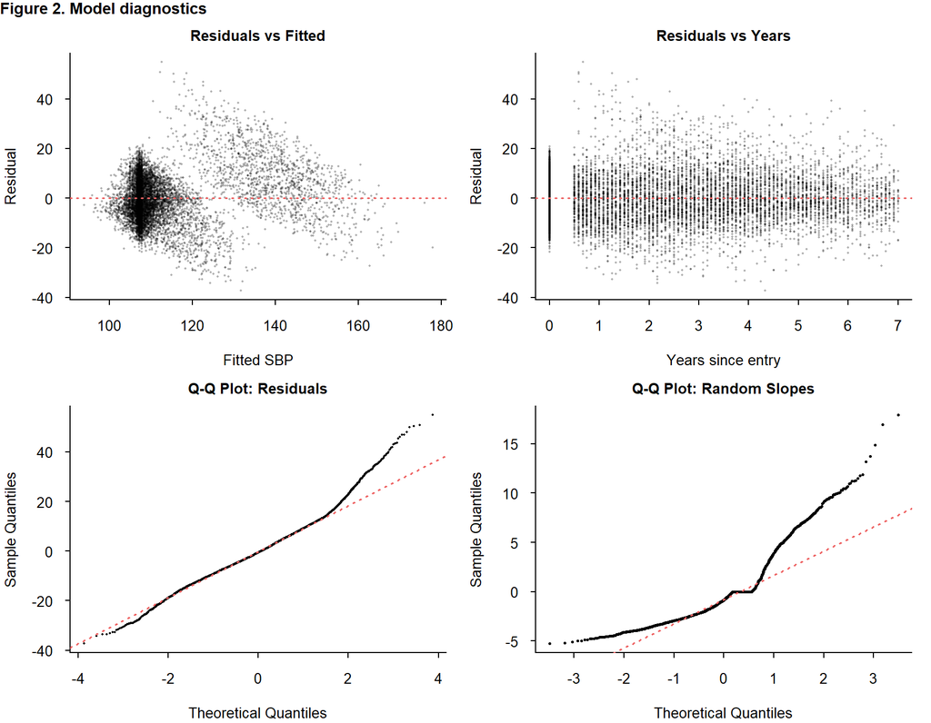

## Modeling

A linear mixed-effects model was constructed to evaluate the association between baseline risk factors and the rate of change in SBP. The model included years since entry, age (per 10 years), sex, and BMI category, the interaction of each factor with time, and antihypertensive medication use at each visit as a time-varying covariate. Each participant has a random slope for time. A random intercept was not included because SBP at entry was restricted to the normotensive range, leaving too little between-person variation to estimate it. The medication term adjusts for treatment started during follow-up and should not be read as a treatment effect, because medication is started when BP is high.

Table 1. Associations of baseline factors and medication use with systolic blood pressure over follow-up

|  | β (95% CI) | P value |
| --- | --- | --- |
| Difference in SBP, mmHg |  |  |
| Age, per 10 years | -0.01 (-0.27 to 0.25) | 0.92 |
| Underweight vs normal weight | -2.18 (-3.89 to -0.48) | 0.012 |
| Overweight vs normal weight | 0.04 (-0.94 to 1.02) | 0.93 |
| Obesity vs normal weight | -0.41 (-1.36 to 0.53) | 0.39 |
| Male vs female | -0.66 (-1.40 to 0.08) | 0.080 |
| On BP medication at the visit | -0.54 (-1.21 to 0.14) | 0.12 |
| Difference in annual change in SBP, mmHg/year |  |  |
| Years since entry (reference group) | 2.39 (1.82 to 2.96) | <0.001 |
| Age, per 10 years | -0.01 (-0.18 to 0.17) | 0.95 |
| Underweight vs normal weight | 1.61 (0.43 to 2.79) | 0.008 |
| Overweight vs normal weight | 0.05 (-0.61 to 0.71) | 0.88 |
| Obesity vs normal weight | 0.62 (-0.03 to 1.26) | 0.060 |
| Male vs female | 0.28 (-0.22 to 0.78) | 0.28 |

Difference in SBP: difference at entry for baseline factors, and at visits on versus off medication for BP medication. Difference in annual change: difference in yearly SBP change versus the reference group.  
Reference group: woman aged 50 at entry with normal BMI, not on BP medication. P values use Satterthwaite degrees of freedom.

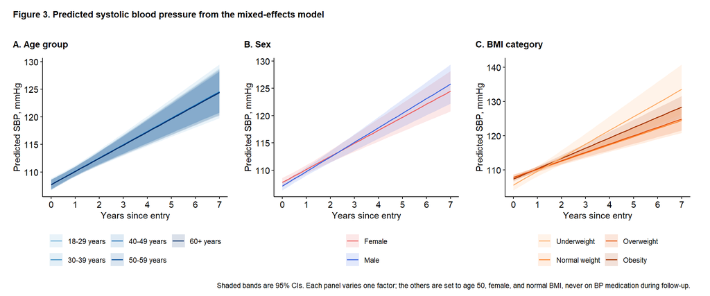

## Summary

For a woman aged 50 at entry with normal BMI and not on BP medication, SBP rose by 2.39 mmHg per year (95% CI 1.82 to 2.96). The rate of change in SBP differed significantly by underweight BMI. At visits on BP medication, SBP was 0.54 mmHg lower (95% CI -1.21 to 0.14) than at visits off medication.